# R Notebook

## Shapiro-Wilk normality test for mpg and wt variables

[output not shown]

## simple linear regression between MPG and WT variables

[output not shown]

## BLUE (Best linear unbiased estimator) properties of the OLS estimator

- The OLS estimator is BLUE if the following assumptions are met:
  - Linearity: The relationship between the independent and dependent variables is linear.
    - Describe Linearity in simple terms
      - The relationship between the independent variable (weight) and the dependent variable (miles per gallon) is linear, meaning that as the weight increases, the miles per gallon decreases in a straight-line fashion.
  - Independence: The residuals (errors) are independent.
    - Describe Independence in simple terms
      - The residuals (the differences between the observed and predicted values) are independent of each other, meaning that the error for one observation does not depend on the error for another observation.
  - Homoscedasticity: The residuals have constant variance.
  - Normality: The residuals are normally distributed.
    - Describe Normality in simple terms
      - The residuals (the differences between the observed and predicted values) are normally distributed, meaning that they follow a bell-shaped curve when plotted.

“Residual” analysis or the LINE tests: - L = Linearity - I = Independence - N = Normality - E = Equal variance (Homoscedasticity)

## Linearity of residuals:

```
plot(lm_model, which=1, col=c("blue"))
```

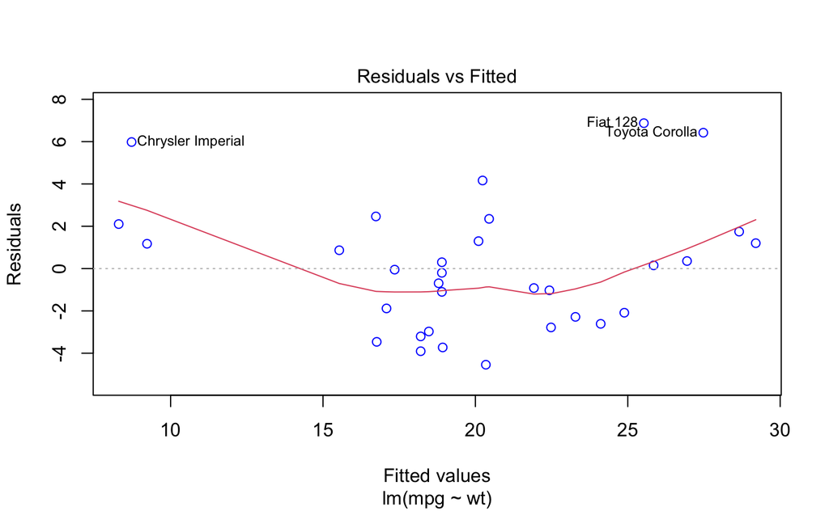

```
summary(lm_model$residuals)
```

```
   Min. 1st Qu.  Median    Mean 3rd Qu.    Max.
-4.5432 -2.3647 -0.1252  0.0000  1.4096  6.8727
```

## Independence of residuals:

```
acf(lm_model$residuals, main="ACF of Residuals")
```

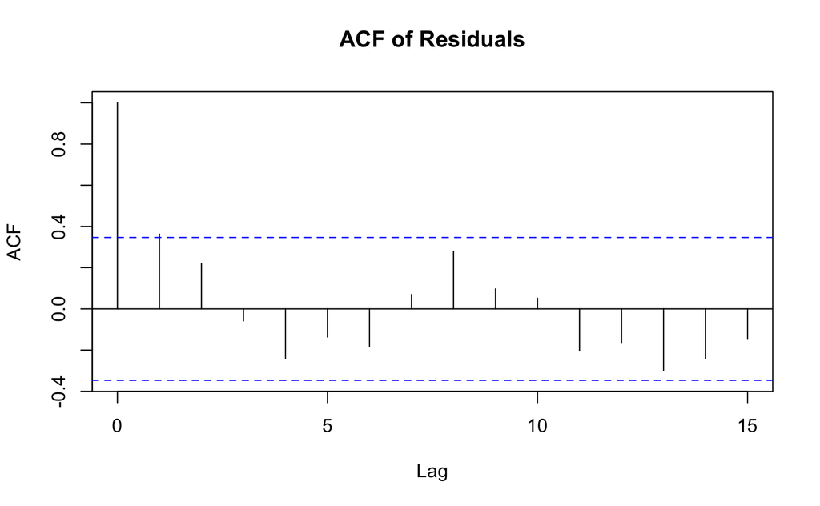

```
library(car)
```

```
durbinWatsonTest(lm_model)
```

```
 lag Autocorrelation D-W Statistic p-value
   1       0.3628798      1.251727   0.012
 Alternative hypothesis: rho != 0
```

p < 0.05 means there is no independence - If this is time series you cannot do prediction but if cross sectional data move ahead.